# Coctail reductions

Jonathan Speh

1/22/2021

# 1 Load and prepare data

## 1.1 Download and inspect

Table 1.1: Tally of ingredients in the raw data

| ingredient | n |
| --- | --- |
| Gin | 176 |
| Fresh lemon juice | 138 |
| Simple Syrup | 115 |
| Vodka | 114 |
| Light Rum | 113 |

## 1.2 Wrangling

- Remove inconsistet naming
- parse ingredients into numeric
- convert into units that were not invented by someone who already had a few of those cocktails to many
- filter out ingredients that are used less than 15 times

### 1.2.1 Parse

Table 1.2: Cocktail data after tidying, filtering and parsing

| name | category | row_id | ingredient_number | ingredient | measure | measure_number |
| --- | --- | --- | --- | --- | --- | --- |
| Gauguin | Cocktail Classics | 1 | 1 | light rum | 2 oz | 59.1400 |
| Gauguin | Cocktail Classics | 1 | 3 | lemon juice | 1 oz | 29.5700 |
| Gauguin | Cocktail Classics | 1 | 4 | lime juice | 1 oz | 29.5700 |
| Fort Lauderdale | Cocktail Classics | 2 | 1 | light rum | 1.5 oz | 44.3550 |
| Fort Lauderdale | Cocktail Classics | 2 | 2 | sweet vermouth | .5 oz | 14.7850 |
| Fort Lauderdale | Cocktail Classics | 2 | 3 | orange juice | .25 oz | 7.3925 |

Table 1.3: Cocktail data in wide format

| name | category | light_rum | lemon_juice | lime_juice | sweet_vermouth | orange_juice | powdered_sugar | dark_rum | cranberry_juice | pineapple_juice | bourbon_whiskey | simple_syrup | cherry_flavored_brandy | light_cream | triple_sec | maraschino | amaretto | grenadine | apple_brandy | brandy | gin | anisette | dry_vermouth | apricot_flavored_brandy | bitters | straight_rye_whiskey | benedictine | egg_white | half_and_half | … |
| --- | --- | --- | --- | --- | --- | --- | --- | --- | --- | --- | --- | --- | --- | --- | --- | --- | --- | --- | --- | --- | --- | --- | --- | --- | --- | --- | --- | --- | --- | --- |
| Gauguin | Cocktail Classics | 59.1400 | 29.57 | 29.5700 | 0.000 | 0.0000 | 0.000 | 0.000 | 0.00 | 0.00 | 0.00 | 0.000 | 0.000 | 0.00 | 0 | 0 | 0 | 0 | 0 | 0 | 0 | 0 | 0 | 0 | 0 | 0 | 0 | 0 | 0 | … |
| Fort Lauderdale | Cocktail Classics | 44.3550 | 0.00 | 7.3925 | 14.785 | 7.3925 | 0.000 | 0.000 | 0.00 | 0.00 | 0.00 | 0.000 | 0.000 | 0.00 | 0 | 0 | 0 | 0 | 0 | 0 | 0 | 0 | 0 | 0 | 0 | 0 | 0 | 0 | 0 | … |
| Cuban Cocktail No. 1 | Cocktail Classics | 59.1400 | 0.00 | 14.7850 | 0.000 | 0.0000 | 14.785 | 0.000 | 0.00 | 0.00 | 0.00 | 0.000 | 0.000 | 0.00 | 0 | 0 | 0 | 0 | 0 | 0 | 0 | 0 | 0 | 0 | 0 | 0 | 0 | 0 | 0 | … |
| Cool Carlos | Cocktail Classics | 0.0000 | 0.00 | 0.0000 | 0.000 | 29.5700 | 0.000 | 44.355 | 59.14 | 59.14 | 0.00 | 0.000 | 0.000 | 0.00 | 0 | 0 | 0 | 0 | 0 | 0 | 0 | 0 | 0 | 0 | 0 | 0 | 0 | 0 | 0 | … |
| John Collins | Whiskies | 0.0000 | 29.57 | 0.0000 | 0.000 | 29.5700 | 0.000 | 0.000 | 0.00 | 0.00 | 59.14 | 14.785 | 0.000 | 0.00 | 0 | 0 | 0 | 0 | 0 | 0 | 0 | 0 | 0 | 0 | 0 | 0 | 0 | 0 | 0 | … |
| Cherry Rum | Cocktail Classics | 36.9625 | 0.00 | 0.0000 | 0.000 | 0.0000 | 0.000 | 0.000 | 0.00 | 0.00 | 0.00 | 0.000 | 44.355 | 29.57 | 0 | 0 | 0 | 0 | 0 | 0 | 0 | 0 | 0 | 0 | 0 | 0 | 0 | 0 | 0 | … |

# 2 Dimension reduction

## 2.1 Principle component analysis

- Unsupervicesd clustering using the tidymodels package.
- Ingredients are predictors
- `all_predictors()` selects variables that have no role
- `recipe()`function sets up (explains) analyses, does not compute anything
- `prep` estimates required parameters from training set

Table 2.1: Assignment of the variables after PCA

| variable | type | role | source |
| --- | --- | --- | --- |
| name | nominal | id | original |
| category | nominal | id | original |
| PC1 | numeric | predictor | derived |
| PC2 | numeric | predictor | derived |
| PC3 | numeric | predictor | derived |
| PC4 | numeric | predictor | derived |
| PC5 | numeric | predictor | derived |

### 2.1.1 tidy PCA and inspect it

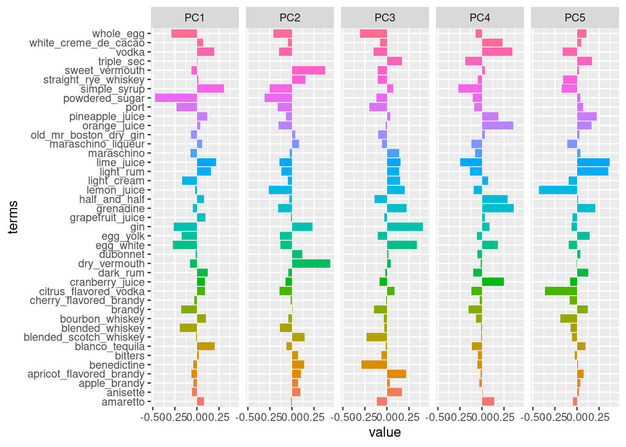

Figure 2.1: Barlot showing the contributions of the different ingredients on the first five components

- Plot shows how much the components contribute to the different components.
  - Bars in different directions –> either or in the drink

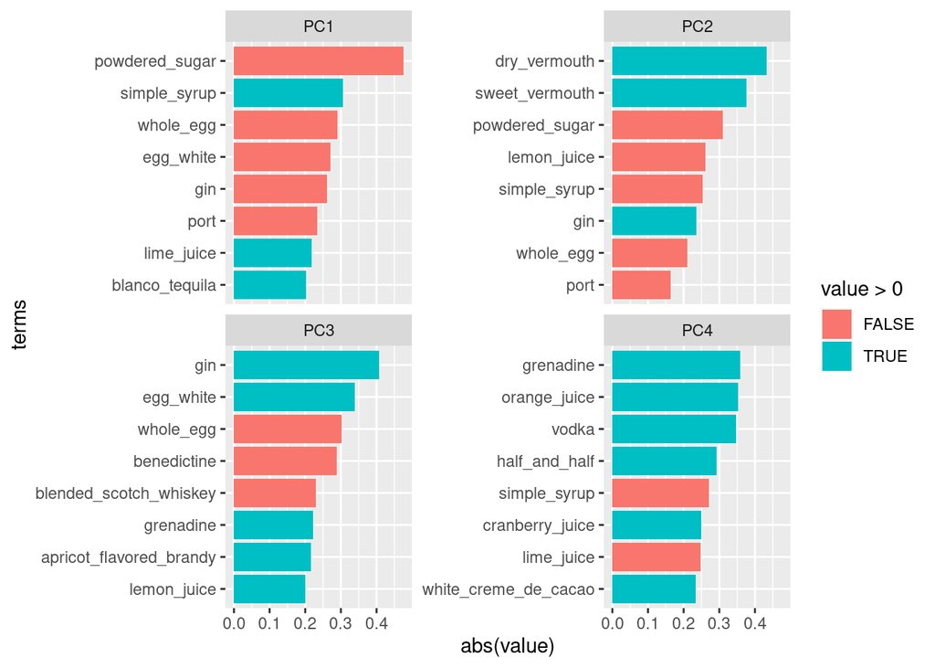

Figure 2.2: Simplified barplot of the first four components. The bars schow the absolute contributionm colours indicated wether positive or negative

- PC1 explains most variante
- powdered sugar vs simple sirup makes largest difference
- sweed / egg gine vs. sirup, lime tequilla
- PC2
- Vermouth vs lemony

### 2.1.2 juice PCA

- by default - 5 compnents
  - reduces 40 dimensions to 5

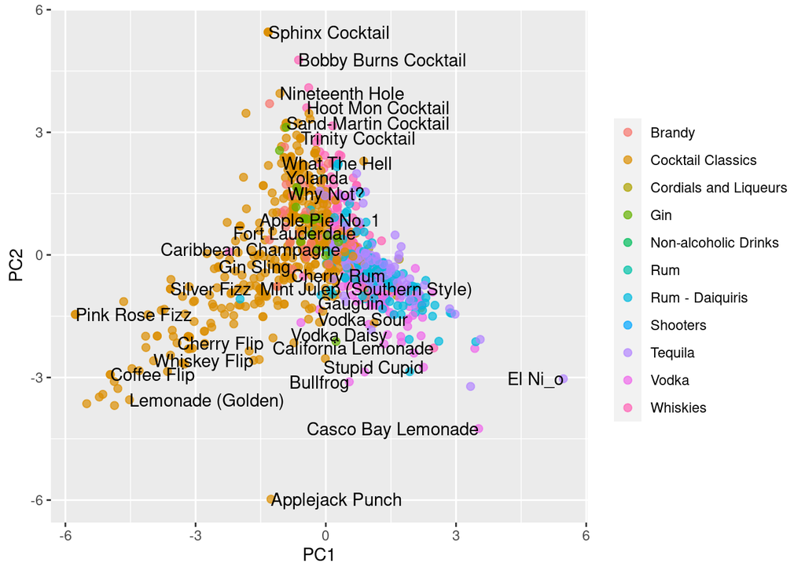

    Figure 2.3: Dotplot of the first two components

- First two components explain most variance in the ingredients

## 2.2 UMAP

- unsupervised ML algorithm for dimension reduction
- tidymodels does not need much changes in the input

Table 2.2: Results of UMAP computation

| variable | type | role | source |
| --- | --- | --- | --- |
| name | nominal | id | original |
| category | nominal | id | original |
| umap_1 | numeric | predictor | derived |
| umap_2 | numeric | predictor | derived |

### 2.2.1 Juice UMAP

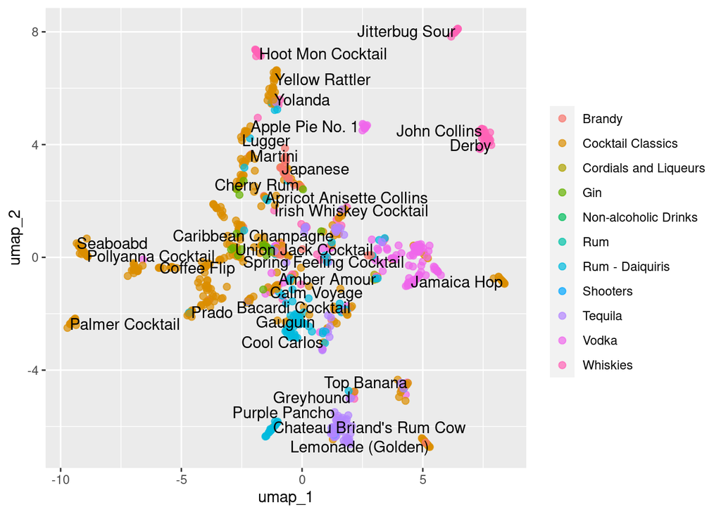

Figure 2.4: UMAP plot indicating similarity of the different cocktails.